Setnayan · Event Hub · prototype 2026-10-17 · v2

# Love Story, two voices

> "or love story. has both a his and her side. it is like he said she said style. how can we present that kind. so people can both read our love story on both perspective." · "no i mean how do we view this love story scene?"

Each moment keeps its date, title, place and photo. Under them, **two voices** under the partners' own first names from the event (never "he" or "she"): only the voices that were written show; a moment nobody wrote for shows today's single line. The words are content and stay **free**. How the whole scene is viewed is a **Look** a couple picks in the Maker's Style tab (one dropdown); how it enters is Animate. Both are ◆ Pro (2026-10-16); a free event gets the default look and the theme's own entrance, and still gets both voices.

Sample words are invented. Phone first, 375 px. Dark mode follows your system, or the switch below.

## Today, live

setnayan.com/cale-ice, ♡ Story, captured read-only at 375 px today. Every moment is date · title · one line, in one column.

[figure not shown]

**Before.** The real page. The placeholder lines are the owner's own test text.

## After: how a guest views the Love Story scene

Three looks, same moments, same two voices. Pick one below; the phone shows it on the real page, and the notes beside it say how a guest moves through it and how it enters.

Look First moment

✕Setnayan

Our love story

2018 · How we met

### How We First Met

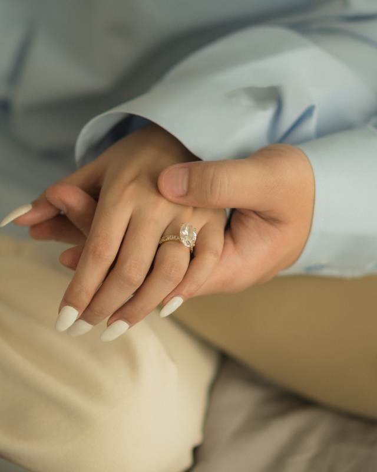

*I*Indalecio

A Friday merienda at a friend's place in Quezon City. She laughed at a joke that was not mine, and I spent the next hour trying to earn the next one.

*C*Claire

He arrived late, carrying a box of ensaymada as an apology. I remember thinking: at least he brought the good kind.

2018 · Falling

### First Date

*C*Claire

Sinigang at a carinderia near Maginhawa, because he said fancy was for the second date. There was no second date. There was a third, a fourth, a hundredth.

April 2022 · Falling

### First out of the country together

Osaka in cherry-blossom season. We got lost on the first morning and never quite minded.

Osaka

August 2025 · The yes

### The Proposal

*I*Indalecio

*C*Claire

He was shaking. I said yes before he finished, then made him finish anyway, because he had clearly practised.

Tagaytay

**After.** Scroll (or swipe) inside the phone. The four moments show the mix a real story has: both voices · only Claire · neither (today's line) · a long voice with Read more.

### Conversation

- **What a guest sees.** The story as a thread: a date chip, the title, the photo, then Indalecio's bubble on the left and Claire's on the right, like reading their messages. Oldest first, so the story reads top to bottom.
- **How they move.** They scroll, the way they read any thread. Nothing to learn, nothing to tap. The next scene follows below as today.
- **How it enters** ◆. The date and photo fade in; the bubbles arrive one after another, a beat apart, like messages landing. Reduced motion: the finished thread.
- **One voice / none.** One bubble alone on its side; no voice, the single line sits centred in italics, as the narrator.

**Recommendation:** Conversation as the scene's default look. It is the owner's own picture ("he said, she said"), it reads at full phone width without squeezing a voice into a lane, and a guest already knows how to read a thread. Two-lane timeline and Swipe cards join the Style dropdown as looks ◆ Pro, beside the shipped Chapters · Essay · Years.

### In every look

- **Who is who.** Indalecio first, Claire second: the partner names as the event already splits them (the same names the Maker's "Added by" shows).
- **Colour.** One colour each, from the event's own palette: the first voice the gold of the "&", the second the navy of the cover's top line. No frame around a voice; a frame is only for something you press (Read more, a dot).
- **Only what was written shows.** One voice: that voice alone, on its side. No voice: today's single line, unchanged.
- **Prints and the essay look** read one line per voice ("Indalecio: … · Claire: …"), so nothing that reads the story today breaks.

## The Maker: one moment's editor

The shipped sheet "Add to our love story" (Studio › Love Story, and the Maker's Love Story panel). Only one block changes: **"A line or two" becomes two fields, one per partner, one under the other.** The look is picked once for the whole scene, in the scene's Style tab, not per moment.

Editing

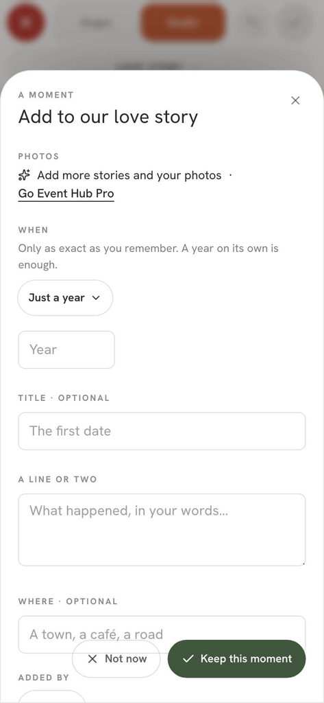

**Before.** As built, 2026-10-08 (side-by-side capture).

A moment

### Add to our love story

Photos

✦ Add more stories and your photos · Go Event Hub Pro

When

Only as exact as you remember. A year on its own is enough.

Just a year ▾ Title · optional

*I*Indalecio *C*Claire

One of you is enough. The moment shows only the voices that wrote.

Where · optional Added by

*I*Indalecio*C*Claire

✕ Not now✓ Keep this moment

**After.** Two fields under the partners' names replace "A line or two". A moment written before today keeps its line in a folded row above them, still editable, still what guests read until a voice is written.

- **Which field is kept.** The existing `line` is kept as the **fallback** ("told together"), not as partner A's. Today's lines are written as "we" ("He asked. She said yes…"); putting them under one name would misattribute them. Nothing is moved, nothing is lost.
- **New moments** see exactly two fields. The folded "Told together" row appears only on a moment that already has a line and no voices.
- **Required:** at least one of the three (a voice, or the together line). Each voice has the same 600-character limit the line has.
- **"Added by" stays** as it is (who added the moment). The builder may hide it once both voices are written; not decided here.
- **Free / Pro unchanged:** five moments, no photos, on a free event. Voices do not count as moments. The look and the entrance are Pro; the default look is free.

## For the builder

[output not shown]